# Week 12: Shiny

## Introducing Shiny

[figure not shown]

- R package that makes it easy to build interactive web apps straight from R.
- Let users interact with your data and your analysis.
- Host standalone apps on a webpage or embed them in R Markdown documents or build dashboards.

## Paradigms for interactive viz

### javascript (d3)

- Very flexible UI.
- No backend; computing is done in browser

### R Shiny

- More constrained UI, very flexible backend
- Computing is done on server.

[figure not shown]

[figure not shown]

## `ui` and `server`

Every shiny app has two components.

### `ui`

- Describes how the webpage will be laid out.
- Handles user input.

### `server`

- Takes input and handles calculations and plot generation.
- A slightly tinkered with R script.

All information that is passed back and forth between these components lives in `input` and `output`.

## Shiny architecture

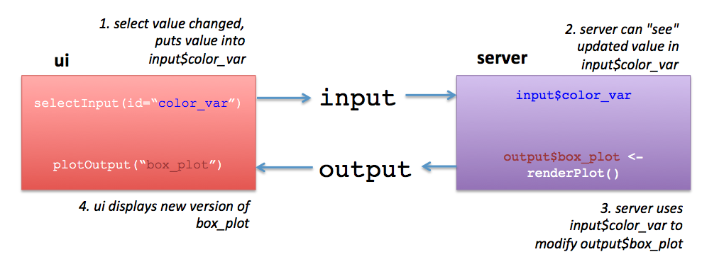

## App 1: app structure

## App 1: linking `ui` and `server`

### Goals

- Create two `ggplots`
- Create simple webpage layout to display plots
- Add user input options to webpage
- Use input to modify plots

### Add input

Paste the following code where it says “Add User Interface Element here” in `app.R`. If you run the app again, you should see a control, but it doesn’t change the plot.

```r
selectInput("color_opts", "Select Category to Color With",
        choices = select_color_options)
```

### Connect to plot

Change the color aesthetic to the following:

```r
color = input$color_opts
```

### Extend

Add a second input categority and it link to a plot.

## What we know

- The architecture of shiny apps
- How `ui` and `server` communicate through `output` and `input`
- How `ui` displays plots (using `plotOutput`)
- Adding a control (a `selectInput`)
- Connecting that control to our plots using `input`

## App 2: Reactives

## Reactives

**Reactive**: a bit of code that runs whenever the controls that map to it are changed.

This will allow us to filter the dataset by adjusting a slider.

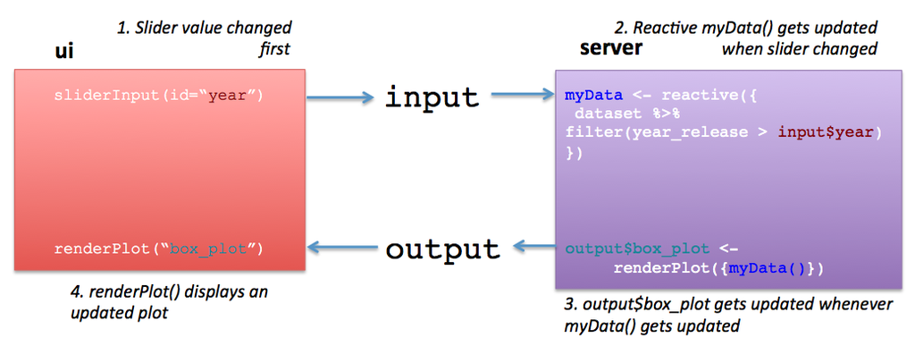

### Link slider

Add a `dplyr` chain after `biopics` inside the reactive to subset the data set to only include films after the specified date.

### Plug in plot 2

Modify the code for plot 2 so that the subsetting also occurs there.

## App 3: Observe-update

## Observe-update

`Observe()` a bit of code that runs whenever the controls that map to it are changed, but unlike `reactive()` doesn't output a specific object.

Can be used to update `ui` after data set changes.

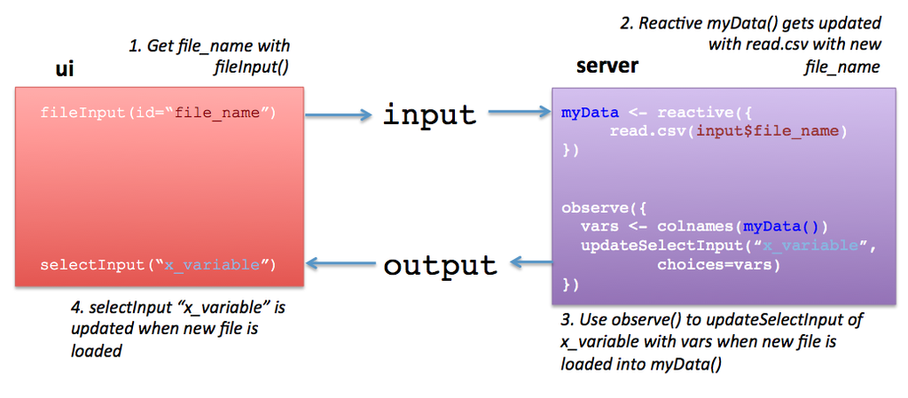

### Adding an input

Add a `selectInput` to filter on a particular category within our category variable. This requires changing the `ui`, updating the plot in the `server` and updating `observe()` to update the `ui`.